### Historia de la moneda de Costa Rica

- **Época Precolombina:** las transacciones se daban por medio del intercambio de alimentos (sal,cacao,maíz,plátanos,yuca,frijoles,etc.) o de otros bienes (herramientas,cerámica,algodón,mantas y objetos de oro).
- **1492:** Cristóbal Colón toca tierra firme por primera vez en suelos costarricenses; razón por la que la moneda de Costa Rica es denominada Colón. Con la llegada de los españoles se estableció el sistema monetario español y las monedas eran fabricadas e oro y plata.
- **1821:** Independencia de Costa Rica. Se siguió utilizando el sistema monetario español.
- **1858:** Se funda el primer banco en Costa Rica, *El Banco Nacional Costarricense*; en el cual se emitieron billetes de 1, 2, 10, 20 pesos.
- **1896:** Reforma monetaria. Se estableció, entre otras cosas, el Colón como unidad monetaria, dividido en 100 partes llamadas céntimos, que son las que seguimos utilizando hoy en día.
- **Desde 1950:** el Banco Central es el encargado de llevar a cabo la emisión de monedas y de dictar la política monetaria del país.
- **En la actualidad:** cuando viajes a Costa Rica te llamará la atención que los billetes son muy coloridos y cuentan con imágenes de seis de los ecosistemas que conforman la biodiversidad del país. Son una singular muestra, de la riqueza natural que ha colocado a Costa Rica en el mapa mundial como un país en el que la biodiversidad e interés por la naturaleza forman parte de su identidad.

### El Colón

**El Colón** es la moneda de Costa Rica, denominada así por Cristóbal Colón. El código de la divisa de Colones es CRC y el símbolo del Colón es ₡.

- Actualmente circulan casi 26 millones de piezas de ₡500, y con la nueva contratación subiran a unos 32 millones.
- El Banco Central de Costa Rica ha puesto en circulación una cantidad importante de monedas, casi 600 millones de piezas, cerca de 150 piezas de monedas por persona.
- Las necesidades de monedas adicionales es una de las variables que se considera para estimas las compras.
- Las monedas de ₡5 se retirarán en el 2020 y las monedas de ₡10 en el 2022, ya que su costo supera su valor facial y además tienen muy poco uso.
- El Banco Central contrató 25 millones de monedas adicionales, que servirán para atender las necesidades del fin de año.
- Entre las principales actividades se encuentran el pago de la recolección de café, la distribución de aguinaldos y las devoluciones en efectivo que realizan los comercios en Navidad.
- Cada pieza de ¢500 tienen un costo de fabricación de ¢45,01; la de ¢100 de ¢39,19 y las de ¢50 de ¢35,26.

### Monedas circulantes en Costa Rica

| Denominación | Metal | Forma | Diámetro |
| --- | --- | --- | --- |
| 5 | Acero cromado | Circular | 26 mm |
| 5 | Bronce al Aluminio | Circular | 21,5 mm |
| 5 | Aluminio | Circular | 21,5 mm |
| 10 | Acero cromado | Circular | 28,5 mm |
| 10 | Latón | Circular | 23,5 mm |
| 10 | Aluminio | Circular | 23,5 mm |
| 10 | Aluminio | Circular | 23,5 mm |
| 20 | Acero cromado | Circular | 31,3 mm |
| 25 | Bronce al Aluminio | Circular | 25,5 mm |
| 50 | Bronce al Aluminio | Circular | 27,5 mm |
| 100 | Latón | Circular | 29,5 mm |
| 500 | Bronce al Aluminio | Circular | 33 mm |

### Cantidad de unidades por año de monedas de ₡5, ₡10 y ₡25

| Denominación | Año | Cantidad de Piezas |
| --- | --- | --- |
| 5 | 2,011 | 125,230,937 |
| 5 | 2,012 | 54,644,000 |
| 5 | 2,013 | 70,496,000 |
| 5 | 2,014 | 170,502,198 |
| 5 | 2,015 | 112,137,386 |
| 5 | 2,016 | 59,560,025 |
| 5 | 2,017 | 5,578,097 |
| 5 | 2,018 | 37,787,113 |
| 5 | 2,019 | 46,785,113 |
| 10 | 2,011 | 15,877,526 |
| 10 | 2,012 | 128,927,526 |
| 10 | 2,013 | 173,215,526 |
| 10 | 2,014 | 134,375,740 |
| 10 | 2,015 | 85,242,946 |
| 10 | 2,016 | 35,567,523 |
| 10 | 2,017 | 13,308,674 |
| 10 | 2,018 | 52,542,678 |
| 10 | 2,019 | 42,342,678 |
| 25 | 2,011 | 59,971,293 |
| 25 | 2,012 | 50,306,293 |
| 25 | 2,013 | 42,311,293 |
| 25 | 2,014 | 30,574,704 |
| 25 | 2,015 | 15,780,641 |
| 25 | 2,016 | 3,573,684 |
| 25 | 2,017 | 26,641,811 |
| 25 | 2,018 | 19,358,159 |
| 25 | 2,019 | 25,158,159 |

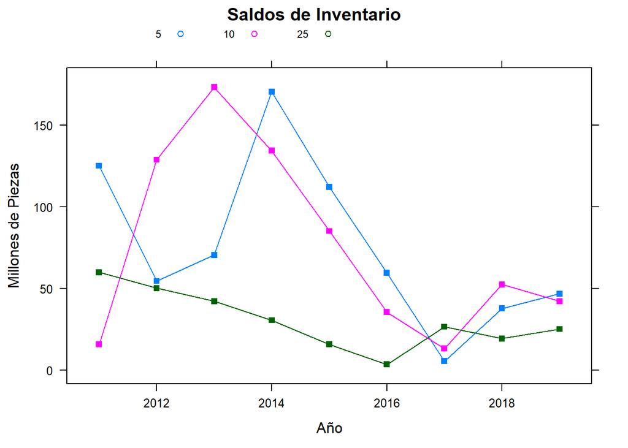

### Cantidad de unidades por año de monedas de ₡50, ₡100 y ₡500

| Denominación | Año | Cantidad de Piezas |
| --- | --- | --- |
| 50 | 2,011 | 18,191,888 |
| 50 | 2,012 | 11,632,000 |
| 50 | 2,013 | 38,216,000 |
| 50 | 2,014 | 30,738,798 |
| 50 | 2,015 | 17,863,268 |
| 50 | 2,016 | 6,113,423 |
| 50 | 2,017 | 20,039,192 |
| 50 | 2,018 | 14,365,743 |
| 50 | 2,019 | 24,365,743 |
| 100 | 2,011 | 61,487,062 |
| 100 | 2,012 | 41,832,062 |
| 100 | 2,013 | 34,892,062 |
| 100 | 2,014 | 17,083,413 |
| 100 | 2,015 | 3,949,868 |
| 100 | 2,016 | 24,567,915 |
| 100 | 2,017 | 8,340,103 |
| 100 | 2,018 | 11,746,503 |
| 100 | 2,019 | 15,643,503 |
| 500 | 2,011 | 32,864,157 |
| 500 | 2,012 | 28,359,157 |
| 500 | 2,013 | 26,046,157 |
| 500 | 2,014 | 20,487,815 |
| 500 | 2,015 | 10,041,000 |
| 500 | 2,016 | 4,834,719 |
| 500 | 2,017 | 17,663,645 |
| 500 | 2,018 | 19,514,145 |
| 500 | 2,019 | 19,511,145 |

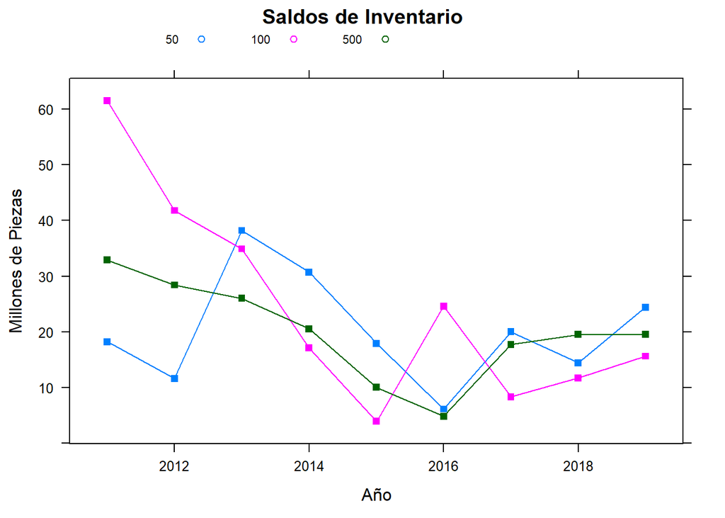